# Assignment-b4

April Hwang

2023-11-28

# Setup

```r
library(janeaustenr)
library(stringr)
library(tidytext)
library(stopwords)
library(ggplot2)
suppressPackageStartupMessages(library(tidyverse))
suppressPackageStartupMessages(library(dplyr))
```

# Exercise 1 (37.5 points)

For this exercise, I will take the book *Emma* from the `janeaustenr` package and make a plot of the most common words in the book. I will be removing stop words using the `stopwords` package.

Link to the `stopwords` package is available here: https://github.com/quanteda/stopwords

## One-row-per-line format

```r
original_books <- austen_books() %>%
  group_by(book) %>%
  mutate(line = row_number(),
         chapter = cumsum(str_detect(text, regex("^chapter [\\divxlc]",
                                                 ignore_case = TRUE)))) %>%
  ungroup()

original_books
```

```
## # A tibble: 73,422 × 4
##    text                    book                 line chapter
##    <chr>                   <fct>               <int>   <int>
##  1 "SENSE AND SENSIBILITY" Sense & Sensibility     1       0
##  2 ""                      Sense & Sensibility     2       0
##  3 "by Jane Austen"        Sense & Sensibility     3       0
##  4 ""                      Sense & Sensibility     4       0
##  5 "(1811)"                Sense & Sensibility     5       0
##  6 ""                      Sense & Sensibility     6       0
##  7 ""                      Sense & Sensibility     7       0
##  8 ""                      Sense & Sensibility     8       0
##  9 ""                      Sense & Sensibility     9       0
## 10 "CHAPTER 1"             Sense & Sensibility    10       1
## # ℹ 73,412 more rows
```

## One-token-per-row format

```r
tidy_books <- original_books %>%
  unnest_tokens(output = word, input = text)

tidy_books
```

```
## # A tibble: 725,055 × 4
##    book                 line chapter word
##    <fct>               <int>   <int> <chr>
##  1 Sense & Sensibility     1       0 sense
##  2 Sense & Sensibility     1       0 and
##  3 Sense & Sensibility     1       0 sensibility
##  4 Sense & Sensibility     3       0 by
##  5 Sense & Sensibility     3       0 jane
##  6 Sense & Sensibility     3       0 austen
##  7 Sense & Sensibility     5       0 1811
##  8 Sense & Sensibility    10       1 chapter
##  9 Sense & Sensibility    10       1 1
## 10 Sense & Sensibility    13       1 the
## # ℹ 725,045 more rows
```

## Remove stop words

```r
cleaned_books <- tidy_books %>%
  anti_join(get_stopwords())
cleaned_books
```

```
## # A tibble: 325,084 × 4
##    book                 line chapter word
##    <fct>               <int>   <int> <chr>
##  1 Sense & Sensibility     1       0 sense
##  2 Sense & Sensibility     1       0 sensibility
##  3 Sense & Sensibility     3       0 jane
##  4 Sense & Sensibility     3       0 austen
##  5 Sense & Sensibility     5       0 1811
##  6 Sense & Sensibility    10       1 chapter
##  7 Sense & Sensibility    10       1 1
##  8 Sense & Sensibility    13       1 family
##  9 Sense & Sensibility    13       1 dashwood
## 10 Sense & Sensibility    13       1 long
## # ℹ 325,074 more rows
```

## Select *Emma*

```r
em <- cleaned_books %>%
  filter(book == 'Emma')

em
```

```
## # A tibble: 72,418 × 4
##    book   line chapter word
##    <fct> <int>   <int> <chr>
##  1 Emma      1       0 emma
##  2 Emma      3       0 jane
##  3 Emma      3       0 austen
##  4 Emma      8       0 volume
##  5 Emma     12       1 chapter
##  6 Emma     15       1 emma
##  7 Emma     15       1 woodhouse
##  8 Emma     15       1 handsome
##  9 Emma     15       1 clever
## 10 Emma     15       1 rich
## # ℹ 72,408 more rows
```

## Count words

```r
common_words <- em %>%
  count(word, sort = TRUE)

common_words
```

```
## # A tibble: 7,226 × 2
##    word        n
##    <chr>   <int>
##  1 mr       1153
##  2 emma      786
##  3 mrs       699
##  4 miss      599
##  5 must      567
##  6 much      486
##  7 said      484
##  8 one       442
##  9 every     435
## 10 harriet   415
## # ℹ 7,216 more rows
```

## Plot top ten most common words from *Emma*

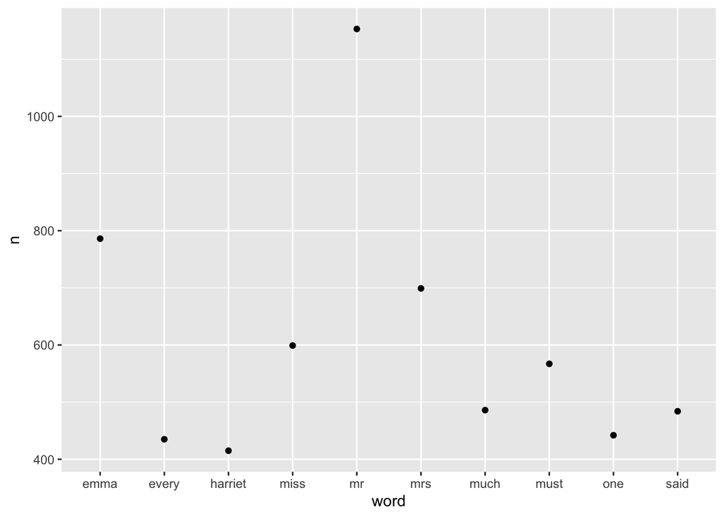

```r
plot <- common_words %>%
  slice_max(n, n = 10) %>%
  ggplot(aes(x = word, y = n)) +
    geom_point()

plot
```

# Exercise 2 (37.5 points)

For this exercise, I will make a function called `bunny_latin` that converts words to my own version of Pig Latin.

For the rearrangement component, I will move the last two letters from the end to the beginning. For the addition component, I will add the last letter to the end of the word following the rearrangement. For example, if the word is ‘apple’, it will first rearrange the word by moving the last two letters to the beginning (‘leapp’), then add the last letter to the end of the word (‘leappp’)

```r
#take last two letters of word
#last_two <- str_sub(words, -2, -1)

#word minus last two letters
#first <- str_sub(words, 1, -3)

#last letter of word
#last_letter <- str_sub(first, -1)

#bunny latin
#bunny_latin <- str_c(last_two, first, last_letter)
```

```r
bunny_latin <- function(x) {
  last_two <- str_sub(x, -2, -1)
  first <- str_sub(x, 1, -3)
  last_letter <- str_sub(first, -1)
  str_c(last_two, first, last_letter)

}
```